# WILD 591 – Spatial Population Modeling

Lesson 5: Point Patterns

Mahdieh Tourani

2026-10-07

# Where we’re going

## Roadmap for today

1. Point pattern and point process
2. Spatial randomness
3. Point pattern analysis

# 1.1 Point pattern

## Point data

> Distinct locations in space

Point data are among the most common spatial data types in ecology:

- individual trees
- bird nests
- habitat patches
- patchy disturbances such as burrows
- locations of species occurrence
- origin points of an invasion

## Point pattern

> A set of spatial coordinates of discrete “events” or individuals observed inside a specified boundary.

Typical point pattern analysis questions:

- Are the points **aggregated, uniform, or random**?
- Does that **change with scale**?
- **What process** produced it?

## Three processes, one pattern

How to disentangle dispersal, habitat heterogeneity, and plant-plant interactions as causes of conspecific aggregation? (Lara-Romero et al. 2016 on canvas)

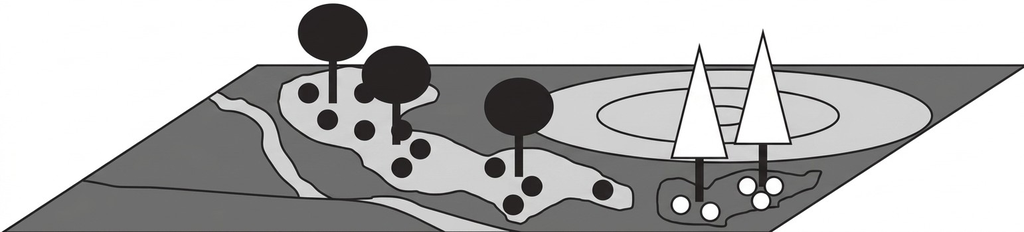

## Spatial dispersion

> The arrangement of points in space relative to one another
- **Aggregated (clumped)**: Points cluster together
- **Random**: Points are distributed independently.
- **Regular (uniform)**: Points are evenly spaced.

```r
library(spatstat)   # startup banner suppressed via message: false

W1 <- owin(c(0, 1), c(0, 1))
set.seed(3)

op <- par(mfrow = c(1, 3))
plot(rMatClust(25, 0.05, 4, win = W1), pch = 19, cex = 2,
     main = "(a) aggregated")

plot(rpoispp(100, win = W1), pch = 19, cex = 2,
     main = "(c) random")

plot(rMaternII(400, 0.045, win = W1), pch = 19, cex = 2,
     main = "(b) uniform (regular)")

par(op)
```

## Dispersion is scale dependent

```r
library(spatstat)

W1 <- owin(c(0, 1), c(0, 1))
set.seed(3)

op <- par(mfrow = c(1, 3), mar = c(0.5, 0.5, 2.4, 0.5))
for (s in c(0.03, 0.08, 0.18)) {
  plot(rMatClust(12, s, 8, win = W1), pch = 19, cex = 2,
       main = paste("aggregated, scale =", s))
}
par(op)
```

# 1.2 Anatomy of a point pattern

## Characteristics

All the methods here need **x–y coordinates** of point locations, plus:

- a **window**: the study area boundary
- optionally **marks**: attributes of points, categorical (e.g., used vs available, predator vs prey) or continuous (e.g., biomass, height)
- optionally **covariates**: as a pixel image, e.g., elevation.

## Sensitivity to window

**Assumption:** the pattern was generated by a *single* point process over the entire study area.

So the delineation of the study area, its size and location, affects the pattern you observe.

Windows can be rectangular or highly irregular polygons.

## Point pattern information content

```r
set.seed(11)
Wd <- owin(c(0, 10), c(0, 10))
Xd <- rMatClust(0.12, 1.1, 4, win = Wd)
n  <- npoints(Xd)

op <- par(mfrow = c(2, 2), mar = c(0.5, 0.5, 2.4, 0.5))

# (a) points in a window
plot(Xd, pch = 19, cex = 2, main = "(a) points + window (boundary)")

# (b) bivariate mark: used / unused
used <- factor(sample(c("used", "unused"), n, TRUE, prob = c(0.35, 0.65)))
plot(ppp(Xd$x, Xd$y, window = Wd, marks = used),
     cols = c("grey60", "firebrick"), chars = c(1, 19), cex = 2,
     main = "(b) bivariate mark")

# (c) continuous mark: size
sz <- rlnorm(n, log(1), 0.5)
plot(ppp(Xd$x, Xd$y, window = Wd, marks = sz),
     markscale = 0.45, main = "(c) continuous mark")

# (d) points on an underlying gradient
gg <- seq(0.1, 9.9, length.out = 60)
grad <- im(outer(gg, gg, function(yy, xx) sin(xx / 2.6) + cos(yy / 3.1)),
           xcol = gg, yrow = gg)
plot(grad, main = "(d) points on a covariate", ribbon = FALSE)
plot(Xd, add = TRUE, pch = 3, cex = 1, col = "white")
par(op)
```

# 2.1 Point processes

## Poisson point process

> A **point process** is a random process producing realizations of point patterns across space and/or time.

The most common: the **Poisson point process** — points are independently distributed in space, described by their intensity λ.

- First-Order Intensity λ: Describes the density of points across space.
- Second-Order Relationships: Relate to the spatial interaction between points (e.g., attraction, competition).

## Point intensity

First-Order Intensity λ: Describes the density of points across space:

- **Homogeneous** (= stationary) — intensity is constant across the window
- **Inhomogeneous** (= non-stationary) — intensity varies across space

Also **isotropy** — the process does not change with direction.

## Thinned point processes

> A **thinned** point process is one where the observed points are a *sample* of the underlying process.

Thinning creates inhomogeneity in the intensity function **independent of the underlying process** from biology (e.g., mortality) or study design.

# 2.2 Summarizing point patterns

## Numerical summaries

> **Numerical** summaries are global, one number for the whole study area.

e.g., **mean/variance ratio** of quadrat counts, against a Poisson expectation:

| Relationship | Interpretation |
| --- | --- |
| mean > variance | regularity |
| mean ≈ variance | randomness |
| mean < variance | aggregation |

But these give **no information about scale**, and they are contingent on how you drew the quadrats.

## Functional summaries

> **Functional** summaries are curves over distance *r*, which is how you get at scale.

**First-order**: summarize points individually, no explicit relation to other points. The intensity function λ(*x*).

**Second-order**: statistical relationships estimated from information in **pairs** of points. Number of points within distance *r* of a focal point.

Higher-order statistics exist (triplets of points) but the overwhelming majority of practice is first- and second-order.

# 3.1 Null models

## Complete spatial randomness

> a homogeneous Poisson process: Points occur independently with constant intensity

Two assumptions:

1. the number of points *n* in a region follows a Poisson distribution with mean λ = *n*/*A*
2. given *n*, points are an independent random sample, equally likely anywhere — uniform over the study region

## Monte Carlo envelopes

Simulate complete spatial randomness many times, at the observed *n*. Take the range of simulated curves as a **confidence envelope** (Baddeley et al. 2014).

If the observed curve falls outside, there is evidence of pattern differing from complete spatial randomness.

## Other null models

- **Cluster point processes** — assume aggregation
  - **Matérn Cluster**: “Parent” points are random; “offspring” are distributed uniformly within a radius $r$ around parents.
  - **Thomas Process**: Offspring are distributed around parents using a bivariate normal (Gaussian) distribution.
- **Inhibition processes** — assume regularity
  - **Matérn Inhibition**: Points are generated but deleted if they fall within a competitive threshold distance $r$ of another point.
- **Environmental gradients** — use a known resource gradient as the null, then ask whether points are aggregated *above and beyond* it (Melles et al. 2009)

## Functions

```r
set.seed(21)
px <- c(5.0, 6.9, 3.3, 7.6, 4.4, 8.4, 2.4, 6.1, 3.8, 7.1)
py <- c(5.0, 6.4, 6.8, 3.6, 3.1, 6.9, 3.9, 8.1, 2.0, 5.2)

op <- par(mfrow = c(1, 3), mar = c(0.6, 0.6, 2.6, 0.6))

## (a) K / L : everything inside a disc of radius r
plot.new(); plot.window(xlim = c(0, 10), ylim = c(0, 10), asp = 1)
symbols(px[1], py[1], circles = 3.2, inches = FALSE, add = TRUE,
        bg = "grey92", fg = "grey40")
segments(px[1], py[1], px[1] + 3.2, py[1], lty = 2)
text(px[1] + 1.6, py[1] + 0.4, "r", font = 3, cex = 2)
points(px, py, pch = 19, cex = 2)
points(px[1], py[1], pch = 15, cex = 2.5, col = "firebrick")
box(col = "grey50")
title("(a) K, L : all points within r", cex.main = 2)

## (b) g : a ring at radius r, smoothed
plot.new(); plot.window(xlim = c(0, 10), ylim = c(0, 10), asp = 1)
symbols(px[1], py[1], circles = 3.6, inches = FALSE, add = TRUE,
        bg = "grey92", fg = NA)
symbols(px[1], py[1], circles = 2.8, inches = FALSE, add = TRUE,
        bg = "white", fg = NA)
symbols(px[1], py[1], circles = 3.2, inches = FALSE, add = TRUE,
        fg = "grey35", lwd = 2)
points(px, py, pch = 19, cex = 2)
points(px[1], py[1], pch = 15, cex = 2.5, col = "firebrick")
text(px[1] + 1.7, py[1] + 0.4, "r", font = 3, cex = 2)
box(col = "grey50")
title("(b) g : points in a ring at r", cex.main = 2)

## (c) G : nearest neighbour only
plot.new(); plot.window(xlim = c(0, 10), ylim = c(0, 10), asp = 1)
points(px, py, pch = 19, cex = 2)
points(px[1], py[1], pch = 15, cex = 2.5, col = "firebrick")
d <- sqrt((px - px[1])^2 + (py - py[1])^2); d[1] <- Inf
nnb <- which.min(d)
arrows(px[1], py[1], px[nnb], py[nnb], length = 0.12, lwd = 2.5,
       col = "firebrick")
box(col = "grey50")
title("(c) G : nearest neighbour distance", cex.main = 2)
par(op)
```

## Ripley’s *K*

The degree of spatial aggregation of points within a circle of radius *r*, compared to complete spatial randomness:

$$K(r) = \frac{E}{\lambda}$$

where λ = *n*/*A* and *E* = expected number of points within *r* of an arbitrarily chosen point, **excluding that point**.

- *K*(*r*) larger than expected → clustering
- *K*(*r*) smaller than expected → regularity

## *K* under CSR, and the *r*² problem

Area of a circle is π*r*², so under complete spatial randomness the expected count is $E_{\text{CSR}} = \lambda \pi r^2$, giving

$$K(r)_{\text{CSR}} = \pi r^2$$

That grows quadratically, which makes plots hard to read — deviations at large *r* dominate visually.

## Linearizing to *L* — two conventions

**Expectation = *r*:**
$$\hat L(r) = \sqrt{K(r)/\pi}$$
aggregation if *L*(*r*) > *r*; regularity if *L*(*r*) < *r*

**Expectation = 0:**
$$\hat L(r) = \sqrt{K(r)/\pi} - r$$
aggregation if *L*(*r*) > 0; regularity if *L*(*r*) < 0

**Always check which one a figure uses.**

## How *K* is actually computed

$$\hat K(r) = A \frac{\sum_i \sum_{j \neq i} w_{ij} \, I(d_{ij} < r)}{n^2}$$

- $d_{ij}$ — distance between points *i* and *j*
- $I(\cdot)$ — indicator, 1 if $d_{ij} < r$, else 0
- $w_{ij}$ — **weight correcting for edge effects**

Ignore the weights and it simplifies to counting neighbours within *r*, scaled by intensity.

## The pair correlation function *g*

$$g(r) = \frac{dK(r)/dr}{2\pi r}$$

The **slope** of *K* at radius *r*, divided by the circumference at *r*.

- *g*(*r*) = 1 → CSR
- *g*(*r*) > 1 → aggregation
- *g*(*r*) < 1 → regularity

## Why *g* beats *K* for identifying scale

*K* is **cumulative** — all points closer than *r* are used.

So strong aggregation at 5 m makes *K* look aggregated at 10 m too, because *r* = 10 still contains everything inside 5.

*g* is a derivative, so it localizes.

*K* is simply the cumulative version of *g* (Baddeley 2007; Velázquez et al. 2016).

## The *G* function

Cumulative distribution of **nearest-neighbour** distances. The “event-to-event” distribution.

$$\hat G(r) = \frac{1}{N}\sum_i \mathbf{1}(d_i \leq r) \qquad
G(r)_{\text{CSR}} = 1 - \exp(-\lambda \pi r^2)$$

- *G*(*r*) > *G*<sub>CSR</sub>(*r*) → distances shorter than expected → aggregation
- *G*(*r*) < *G*<sub>CSR</sub>(*r*) → longer than expected → regularity

## Marks: bivariate and continuous

**Bivariate (cross) *K*** — for two categorical point types:

$$\hat K_{12}(r) = A \frac{\sum_i \sum_j I(d_{ij} < r)}{n_1 n_2}$$

computed for $K_{12}$ and $K_{21}$, then averaged.

**Mark correlation function** — for continuous marks:

$$\hat K_m(r) = \sum_i \sum_{j \neq i} I_r \, m_i m_j$$

Asks whether large values tend to be near other large values.

## Activity overview

**Format:** Pairs

**Materials:** 2 maps, 1 distance card, ruler

Suppose you have a complete census of elk across a 2km × 2km block of the Blackfoot

Your group’s job: For each distance card, determine with numbers if elk locations on the maps are **aggregated**, **random**, or **regular**?

## Activity: Phase 1

> **0 - 3 minutes.** Look at Map A. In one word, please write down: Are these elk **clustered**, **random**, or **regular**?

> **2 - 4 minutes.** Propose a method to prove with numbers what you committed in the previous step.

## Activity: Phase 2

Here is the measurement we will make: for a typical elk, count how many OTHER elk lie within distance *r* of it.

To know whether that count is a lot, you need to know what **randomness** would have given you.

> There are 60 elk in 4 km². If those 60 elk were scattered **at random** across the block, how many would you expect to find inside a circle of radius *r*?

> Work it out. You have everything you need.

## Activity: Phase 3

> Pick a distance (m) and follow the steps below.
> 1. **Measure the scale bar** on each map with your ruler. Work out how many millimetres equal one metre **on each map**.
> 2. **Decide which map** your question can be answered on. Be ready to justify it.
> 3. **Pick three focal elk.** For each, draw a circle of radius *r* and count how many other elk fall inside.
> 4. Average your three counts → **observed**.
> 5. Compute **expected**, using **the formula your group just derived**.
> 6. Report **observed ÷ expected**. That ratio is your answer.

## Activity: Phase 4

Each group reports one ratio.

| *r* | Expected | Observed | **Ratio** |
| --- | --- | --- | --- |
| 8 m |  |  |  |
| 30 m |  |  |  |
| 100 m |  |  |  |
| 500 m |  |  |  |

**So — are elk clustered?**

## Activity: Phase 4

| *r* | From map | How they got *observed* | Expected | Observed | **Ratio** |
| --- | --- | --- | --- | --- | --- |
| **8 m** | **B** | count inside an 8 mm circle | 0.003 | **0** | **0** |
| **30 m** | **B** | count inside a 30 mm circle | 0.042 | 11.1 | **≈ 260** |
| **100 m** | **B** | The entire herd fits in 60m | 0.471 | 19 | **≈ 40** |
| **500 m** | **A** | count inside a 50 mm circle → no other cluster reached | 11.78 | 19 | **≈ 1.6** |

## Activity: Phase 5

On Map B (one herd, 20 elk in a 180 × 180 m frame), we found **zero** neighbours within 8 m. Ratio equals 0, fewer than random.

> **Have we proved that elk avoid standing close together?**

A **close pair**: two elk standing closer together than 8 m.

Before you can call zero a finding, you have to ask: **would randomness have given us zero too?**

## Activity: Phase 5

**Work it out for Map B, 20 elk in a 180 × 180 m frame.**

density = 20 ÷ 0.0324 km² = **617 elk per km²**

expected neighbours per elk = 617 × π(0.008)² = **0.124**

expected pairs = 20 × 0.124 **÷ 2** = **1.24 pairs**

- Why divide by two? Every pair got counted twice — elk A counts B as a neighbour, and B counts A.
- Randomness on Map B predicts about **1.2** close pairs. You would see **zero about 29% of the time.**

## Activity: Phase 5

What if we change the window?

| Window | Density | Expected pairs | Zero surprising? | Verdict |
| --- | --- | --- | --- | --- |
| The whole 2 × 2 km block | 15/km² | 0.09 | No — ~**91%** of the time | regular, **undetectable** |
| Map B’s 180 m frame | 617/km² | 1.24 | No — ~**29%** of the time | regular, **undetectable** |
| The 60 × 48m patch the herd occupies | 6,944/km² | 14.0 | **Yes** | **regular, and demonstrated** |

## Activity debrief

| What we found | The name for it |
| --- | --- |
| The verdict changes with the distance you ask about | **Dispersion is scale-dependent** |
| We were measuring elk-to-elk distances. No pixel, no quadrat, no grain | *r* is the scale of analysis |
| We couldn’t ask the 8m question on a 2km map | **Extent limits detectable scales** |
| Same *r*, two densities, opposite results | **The null model decides the answer** |

# 3.2 Edge effects

## What goes wrong at the boundary

Near the study area boundary you have no information about points outside.

So a circle of radius *r* centred near the edge contains fewer observed points than the truth.

Uncorrected statistics are therefore **biased** — and biased increasingly at large *r*, because bigger circles overlap the boundary more.

## Corrections

```r
set.seed(8)
ex <- runif(28, 0, 10); ey <- runif(28, 0, 10)

op <- par(mfrow = c(1, 2), mar = c(0.6, 0.6, 2.8, 0.6))

## (a) isotropic weighting
plot.new(); plot.window(xlim = c(-4, 11), ylim = c(-2.5, 12.5), asp = 1)
symbols(8.6, 5, circles = 3.4, inches = FALSE, add = TRUE,
        bg = "grey93", fg = "grey45")
rect(0, 0, 10, 10, border = "grey25", lwd = 2)
points(ex, ey, pch = 19, cex = 0.9)
points(8.6, 5, pch = 15, cex = 1.8, col = "firebrick")
# points that would exist outside but are unobserved
points(c(11.4, 10.9, 11.8), c(4.2, 6.6, 5.4), pch = 1, cex = 1.1,
       col = "grey55")
text(0.2, 11.6, "(a) isotropic weighting", adj = 0, cex = 1.15, font = 2)
text(-3.8, -1.9, "w = 1 / (fraction of\ncircumference inside)",
     adj = 0, cex = 0.95)

## (b) toroidal shift
plot.new(); plot.window(xlim = c(-4, 11), ylim = c(-2.5, 12.5), asp = 1)
rect(0, 0, 10, 10, border = "grey25", lwd = 2)
points(ex, ey, pch = 19, cex = 0.9)
# wrapped copies
points(ex - 10, ey, pch = 1, cex = 0.7, col = "grey60")
points(ex, ey + 10, pch = 1, cex = 0.7, col = "grey60")
arrows(9.4, 11.1, 0.6, 11.1, length = 0.11, lwd = 2, col = "firebrick")
arrows(-1.2, 0.6, -1.2, 9.4, length = 0.11, lwd = 2, col = "firebrick")
text(0.2, 11.9, "(b) translate / toroidal shift", adj = 0, cex = 1.15,
     font = 2)
text(-3.8, -1.9, "wrap the plot onto a torus;\nno weights needed",
     adj = 0, cex = 0.95)
par(op)
```

## When *not* to correct

If the boundary is a **hard, true boundary** for the points, correcting is wrong (Lancaster & Downes 2004).

Examples: a pond edge for aquatic larvae; an island coastline; a fenced enclosure.

The correction assumes points *could* exist outside. Sometimes they can’t.

## What all of this assumes

- **Stationarity** (homogeneity) — intensity constant over space
- **Isotropy** — no directional dependence
- **Complete census**, not a sample

The functions can be extended to inhomogeneous processes (Lab D). Isotropy usually just gets assumed.

On sampling: randomly thinning a Poisson process leaves a Poisson process, so random samples are defensible. **Biased** samples are not.